# DNA_Sequence_Statistics_2

# Q3. Write a function to calculate the AT content of a DNA sequence (ie. the fraction of the nucleotides in the sequence that are As or Ts). What is the AT content of the Mycobacterium leprae TN genome?

```r
#length(lepraeseq)
#leprae_table <- count(lepraeseq,1)
#leprae_table
#leprae_table[1]
#leprae_table[4]
AT_calculator <- function(genome)
{
  genome_table <- count(genome,1)
  A_count <- genome_table[1]
  T_count <- genome_table[4]
  100 * (A_count + T_count)/length(lepraeseq)
}
AT_calculator(lepraeseq)
```

```
##        a
## 42.20325
```

# Q4. Write a function to draw a sliding window plot of AT content. Use it to make a sliding window plot of AT content along the Mycobacterium leprae TN genome, using a windowsize of 20000 nucleotides. Do you notice any relationship between the sliding window plot of GC content along the Mycobacterium leprae genome, and the sliding window plot of AT content?

[output not shown]

[output cut: 271 more lines]

```
## 0.2628662
##         a
## 0.2520957
##         a
## 0.2641207
##         a
## 0.2735448
##         a
## 0.2716478
##         a
## 0.2705462
##         a
## 0.2602348
##         a
## 0.2567466
```

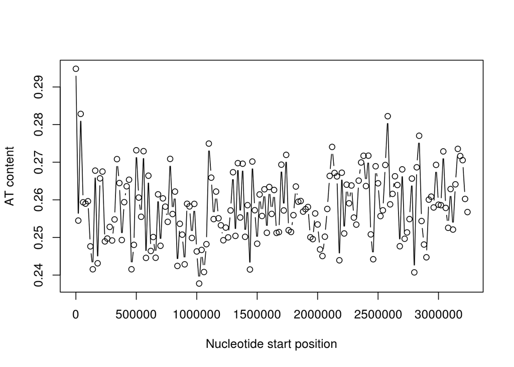

```r
ATslidingwindow <- function(windowsize, genome)
{
  starts <- seq(1, length(genome)-windowsize, by = windowsize)
  n <- length(starts)
  chunkATs <- numeric(n)
  for (i in 1:n)
  {
    chunk <- genome[starts[i]:(starts[i]+windowsize-1)]
    chunkAT <- AT_calculator(chunk)
    print(chunkAT)
    chunkATs[i] <- chunkAT
  }
  plot(starts,chunkATs,type="b",xlab="Nucleotide start position",ylab="AT content")
}
ATslidingwindow(20000, lepraeseq)
```

# Q5. Is the 3-nucleotide word GAC over-represented or under-represented in the Mycobacterium leprae TN genome sequence?

```r
count(lepraeseq, 1)
```

```
##
##      a      c      g      t
## 687041 938713 950202 692247
```

```r
# get G frequency
950202/(687041+938713+950202+692247)
```

```
## [1] 0.2907414
```

```r
# get A frequency
687041/(687041+938713+950202+692247)
```

```
## [1] 0.2102198
```

```r
# get C frequency
938713/(687041+938713+950202+692247)
```

```
## [1] 0.287226
```

```r
count(lepraeseq, 3)
```

```
##
##   aaa   aac   aag   aat   aca   acc   acg   act   aga   agc   agg   agt
## 32093 48714 36319 32592 44777 67449 57326 37409 31957 62473 38946 37470
##   ata   atc   atg   att   caa   cac   cag   cat   cca   ccc   ccg   cct
## 25030 57245 44268 32973 52381 64102 64345 43838 64869 46037 87560 38504
##   cga   cgc   cgg   cgt   cta   ctc   ctg   ctt   gaa   gac   gag   gat
## 78120 82057 89358 57451 29004 39954 64730 36401 43486 61174 40728 58009
##   gca   gcc   gcg   gct   gga   ggc   ggg   ggt   gta   gtc   gtg   gtt
## 66775 80319 83415 62752 44002 81461 47651 69957 33139 60958 65955 50421
##   taa   tac   tag   tat   tca   tcc   tcg   tct   tga   tgc   tgg   tgt
## 21758 32971 29454 25076 48245 43166 78685 31424 49318 67270 67116 45595
##   tta   ttc   ttg   ttt
## 22086 43363 54346 32374
```

```r
# get trinucleotide sum
# yuck, it looks like we're supposed to sum that all by hand ... NO WAY
trinucleotides <- count(lepraeseq, 3)
n <- length(trinucleotides)
trinucleotide_sum <- 0
for (i in 1:n)
{
  trinucleotide_sum <- trinucleotide_sum + trinucleotides[[i]]
}
trinucleotide_sum
```

```
## [1] 3268201
```

```r
# get GAC frequency
GAC_frequency <- 61174/trinucleotide_sum
# GAC is slightly over-represented
GAC_frequency/(0.2907414 * 0.2102198 * 0.287226)
```

```
## [1] 1.066237
```